# Getting and Cleaning Data Course Project

This file describes the approach used in creating an R script producing a tidy dataset per the assignment. It covers, 1. Raw data files 2. Expected output 3. R script approach 4. Result

## Project Rubric and Data

- The Course Project description is located [here](https://class.coursera.org/getdata-014/human_grading/view/courses/973501/assessments/3/submissions)
- The data used for the script is located [here](https://d396qusza40orc.cloudfront.net/getdata%2Fprojectfiles%2FUCI%20HAR%20Dataset.zip)
- My Code Book

## Raw Data Files

The working directory for this script is, “wearableComputing”. The raw data files were downloaded and extracted into the working directory (not vie the script at this time) The file structure looks like this:

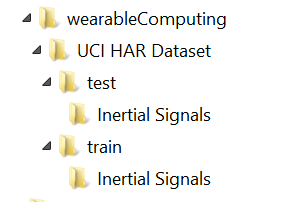

The data is separated into two groups, training and testing

The files referenced or created by the script include,

- *wearableComputing/finalOutput.txt* - this is the tidy dataset!
- *wearableComputing/UCI HAR Dataset/features.txt* - this file provides the titles for the 561 measures collected in the study
- *wearableComputing/UCI HAR Dataset/activity_labels.txt* - the file provides the six activities that were performed in the study
- *wearableComputing/UCI HAR Dataset/test/subject_test.txt* - This file lists the person who performed the study. There were 30 people involved (test group)
- *wearableComputing/UCI HAR Dataset/test/y_test.txt* - This file lists the activity code performed associated with the measure (test group)
- *wearableComputing/UCI HAR Dataset/test/X_test.txt* - This file lists the measures taken through the experiment (test group)
- *wearableComputing/UCI HAR Dataset/train/subject_train.txt* - This file lists the person who performed the study. There were 30 people involved (train group)
- *wearableComputing/UCI HAR Dataset/train/y_train.txt* - This file lists the activity code performed associated with the measure (train group)
- *wearableComputing/UCI HAR Dataset/train/X_train.txt* - This file lists the measures taken through the experiment (train group)

NOTE: The Inertial Signals files were not used because these measures do not have ‘mean’ or ‘std’ in their title

## Expected Output

The expected output is a tidy data set with the average of each variable for each activity and each subject. Keeping with principles of tidy data, I endeavored to produce a dataset shaped as follows:

- Two ID variables, 1 The person performing the test and, 2 the activity performed
- 79 measures - this is the number of measures that have either ‘mean’ or ‘std’ in the title
- There should be 180 rows of data, one for each activity that each person performed (30 people x 6 activities = 180 records).
- The mean of the measures are calculated for each row

The output data frame structure looks as follows,

```r
> str(data2)
'data.frame':      180 obs. of  81 variables:
 $ Person                         : Factor w/ 30 levels "Person 01","Person 02",..: 1 1 1 1 1 1 2 2 2 2 ...
 $ Activity                       : Factor w/ 6 levels "LAYING","SITTING",..: 1 2 3 4 5 6 1 2 3 4 ...
 $ tBodyAcc.mean...X              : num  0.222 0.261 0.279 0.277 0.289 ...
 $ tBodyAcc.mean...Y              : num  -0.04051 -0.00131 -0.01614 -0.01738 -0.00992 ...
 $ tBodyAcc.mean...Z              : num  -0.113 -0.105 -0.111 -0.111 -0.108 ...
 $ tBodyAcc.std...X               : num  -0.928 -0.977 -0.996 -0.284 0.03 ...
 $ tBodyAcc.std...Y               : num  -0.8368 -0.9226 -0.9732 0.1145 -0.0319 ...
 $ tBodyAcc.std...Z               : num  -0.826 -0.94 -0.98 -0.26 -0.23 ...
 $ tGravityAcc.mean...X           : num  -0.249 0.832 0.943 0.935 0.932 ...
 $ tGravityAcc.mean...Y           : num  0.706 0.204 -0.273 -0.282 -0.267 ...
 $ tGravityAcc.mean...Z           : num  0.4458 0.332 0.0135 -0.0681 -0.0621 ...
 $ tGravityAcc.std...X            : num  -0.897 -0.968 -0.994 -0.977 -0.951 ...
 $ tGravityAcc.std...Y            : num  -0.908 -0.936 -0.981 -0.971 -0.937 ...
 $ tGravityAcc.std...Z            : num  -0.852 -0.949 -0.976 -0.948 -0.896 ...
 $ tBodyAccJerk.mean...X          : num  0.0811 0.0775 0.0754 0.074 0.0542 ...
 $ tBodyAccJerk.mean...Y          : num  0.003838 -0.000619 0.007976 0.028272 0.02965 ...
 $ tBodyAccJerk.mean...Z          : num  0.01083 -0.00337 -0.00369 -0.00417 -0.01097 ...
 $ tBodyAccJerk.std...X           : num  -0.9585 -0.9864 -0.9946 -0.1136 -0.0123 ...
 $ tBodyAccJerk.std...Y           : num  -0.924 -0.981 -0.986 0.067 -0.102 ...
 $ tBodyAccJerk.std...Z           : num  -0.955 -0.988 -0.992 -0.503 -0.346 ...
 $ tBodyGyro.mean...X             : num  -0.0166 -0.0454 -0.024 -0.0418 -0.0351 ...
 $ tBodyGyro.mean...Y             : num  -0.0645 -0.0919 -0.0594 -0.0695 -0.0909 ...
 $ tBodyGyro.mean...Z             : num  0.1487 0.0629 0.0748 0.0849 0.0901 ...
 $ tBodyGyro.std...X              : num  -0.874 -0.977 -0.987 -0.474 -0.458 ...
 $ tBodyGyro.std...Y              : num  -0.9511 -0.9665 -0.9877 -0.0546 -0.1263 ...
 $ tBodyGyro.std...Z              : num  -0.908 -0.941 -0.981 -0.344 -0.125 ...
 $ tBodyGyroJerk.mean...X         : num  -0.1073 -0.0937 -0.0996 -0.09 -0.074 ...
 $ tBodyGyroJerk.mean...Y         : num  -0.0415 -0.0402 -0.0441 -0.0398 -0.044 ...
 $ tBodyGyroJerk.mean...Z         : num  -0.0741 -0.0467 -0.049 -0.0461 -0.027 ...
 $ tBodyGyroJerk.std...X          : num  -0.919 -0.992 -0.993 -0.207 -0.487 ...
 $ tBodyGyroJerk.std...Y          : num  -0.968 -0.99 -0.995 -0.304 -0.239 ...
 $ tBodyGyroJerk.std...Z          : num  -0.958 -0.988 -0.992 -0.404 -0.269 ...
 $ tBodyAccMag.mean..             : num  -0.8419 -0.9485 -0.9843 -0.137 0.0272 ...
 $ tBodyAccMag.std..              : num  -0.7951 -0.9271 -0.9819 -0.2197 0.0199 ...
 $ tGravityAccMag.mean..          : num  -0.8419 -0.9485 -0.9843 -0.137 0.0272 ...
 $ tGravityAccMag.std..           : num  -0.7951 -0.9271 -0.9819 -0.2197 0.0199 ...
 $ tBodyAccJerkMag.mean..         : num  -0.9544 -0.9874 -0.9924 -0.1414 -0.0894 ...
 $ tBodyAccJerkMag.std..          : num  -0.9282 -0.9841 -0.9931 -0.0745 -0.0258 ...
 $ tBodyGyroMag.mean..            : num  -0.8748 -0.9309 -0.9765 -0.161 -0.0757 ...
 $ tBodyGyroMag.std..             : num  -0.819 -0.935 -0.979 -0.187 -0.226 ...
 $ tBodyGyroJerkMag.mean..        : num  -0.963 -0.992 -0.995 -0.299 -0.295 ...
 $ tBodyGyroJerkMag.std..         : num  -0.936 -0.988 -0.995 -0.325 -0.307 ...
 $ fBodyAcc.mean...X              : num  -0.9391 -0.9796 -0.9952 -0.2028 0.0382 ...
 $ fBodyAcc.mean...Y              : num  -0.86707 -0.94408 -0.97707 0.08971 0.00155 ...
 $ fBodyAcc.mean...Z              : num  -0.883 -0.959 -0.985 -0.332 -0.226 ...
 $ fBodyAcc.std...X               : num  -0.9244 -0.9764 -0.996 -0.3191 0.0243 ...
 $ fBodyAcc.std...Y               : num  -0.834 -0.917 -0.972 0.056 -0.113 ...
 $ fBodyAcc.std...Z               : num  -0.813 -0.934 -0.978 -0.28 -0.298 ...
 $ fBodyAcc.meanFreq...X          : num  -0.1588 -0.0495 0.0865 -0.2075 -0.3074 ...
 $ fBodyAcc.meanFreq...Y          : num  0.0975 0.0759 0.1175 0.1131 0.0632 ...
 $ fBodyAcc.meanFreq...Z          : num  0.0894 0.2388 0.2449 0.0497 0.2943 ...
 $ fBodyAccJerk.mean...X          : num  -0.9571 -0.9866 -0.9946 -0.1705 -0.0277 ...
 $ fBodyAccJerk.mean...Y          : num  -0.9225 -0.9816 -0.9854 -0.0352 -0.1287 ...
 $ fBodyAccJerk.mean...Z          : num  -0.948 -0.986 -0.991 -0.469 -0.288 ...
 $ fBodyAccJerk.std...X           : num  -0.9642 -0.9875 -0.9951 -0.1336 -0.0863 ...
 $ fBodyAccJerk.std...Y           : num  -0.932 -0.983 -0.987 0.107 -0.135 ...
 $ fBodyAccJerk.std...Z           : num  -0.961 -0.988 -0.992 -0.535 -0.402 ...
 $ fBodyAccJerk.meanFreq...X      : num  0.132 0.257 0.314 -0.209 -0.253 ...
 $ fBodyAccJerk.meanFreq...Y      : num  0.0245 0.0475 0.0392 -0.3862 -0.3376 ...
 $ fBodyAccJerk.meanFreq...Z      : num  0.02439 0.09239 0.13858 -0.18553 0.00937 ...
 $ fBodyGyro.mean...X             : num  -0.85 -0.976 -0.986 -0.339 -0.352 ...
 $ fBodyGyro.mean...Y             : num  -0.9522 -0.9758 -0.989 -0.1031 -0.0557 ...
 $ fBodyGyro.mean...Z             : num  -0.9093 -0.9513 -0.9808 -0.2559 -0.0319 ...
 $ fBodyGyro.std...X              : num  -0.882 -0.978 -0.987 -0.517 -0.495 ...
 $ fBodyGyro.std...Y              : num  -0.9512 -0.9623 -0.9871 -0.0335 -0.1814 ...
 $ fBodyGyro.std...Z              : num  -0.917 -0.944 -0.982 -0.437 -0.238 ...
 $ fBodyGyro.meanFreq...X         : num  -0.00355 0.18915 -0.12029 0.01478 -0.10045 ...
 $ fBodyGyro.meanFreq...Y         : num  -0.0915 0.0631 -0.0447 -0.0658 0.0826 ...
 $ fBodyGyro.meanFreq...Z         : num  0.010458 -0.029784 0.100608 0.000773 -0.075676 ...
 $ fBodyAccMag.mean..             : num  -0.8618 -0.9478 -0.9854 -0.1286 0.0966 ...
 $ fBodyAccMag.std..              : num  -0.798 -0.928 -0.982 -0.398 -0.187 ...
 $ fBodyAccMag.meanFreq..         : num  0.0864 0.2367 0.2846 0.1906 0.1192 ...
 $ fBodyBodyAccJerkMag.mean..     : num  -0.9333 -0.9853 -0.9925 -0.0571 0.0262 ...
 $ fBodyBodyAccJerkMag.std..      : num  -0.922 -0.982 -0.993 -0.103 -0.104 ...
 $ fBodyBodyAccJerkMag.meanFreq.. : num  0.2664 0.3519 0.4222 0.0938 0.0765 ...
 $ fBodyBodyGyroMag.mean..        : num  -0.862 -0.958 -0.985 -0.199 -0.186 ...
 $ fBodyBodyGyroMag.std..         : num  -0.824 -0.932 -0.978 -0.321 -0.398 ...
 $ fBodyBodyGyroMag.meanFreq..    : num  -0.139775 -0.000262 -0.028606 0.268844 0.349614 ...
 $ fBodyBodyGyroJerkMag.mean..    : num  -0.942 -0.99 -0.995 -0.319 -0.282 ...
 $ fBodyBodyGyroJerkMag.std..     : num  -0.933 -0.987 -0.995 -0.382 -0.392 ...
 $ fBodyBodyGyroJerkMag.meanFreq..: num  0.176 0.185 0.334 0.191 0.19 ...
```

## R script approach

The script file is saved in the working directory and called: *run_analysis.R*

The steps performed in the script,

1. Load the activity descriptions and measure titles (from the root directory) into dataframes
2. Create a function that the script iterates through twice via a ‘train’ and ‘test’ variable. The function does the following…,
> 1. Load the measures into a dataframe and add column names from the features file
> 2. Remove those columns that do not have “mean” or “std” in the name
> 3. Load the subject and activity codes into dataframes
> 4. Add the activity descriptions to the measure dataset by looking up codes against the activity_lables.txt file - did this via join method so as to not mistakenly re-order data
> 5. Reformat subject in a more readable way, e.g. “Person 01” and add to to the measure dataset
3. combine the test and train data outputted from the function
4. Create a final tidy dataset by calculate the average for all variables by subject and activity. Used the reshape2 package, melt and dcast functions

## Result

The script writes a table to a text file in the working directory called, *finalOutput.txt*

The method for writing the data complies with the project requirements,

```r
write.table(finalOut, "finalOutput.txt", row.name=FALSE)
```

**The End.**